# **Introduction**

Portfolio construction is a vital task in investment organization, necessitating a careful balance amongst expected returns and risk while accounting for real-world investment restraints. Modern portfolio theory offers a quantitative background for recognizing optimal asset apportionments by using diversification benefits and the statistical properties of asset returns. Nevertheless, the portfolios oblique by theory often diverges from those executed in reality due to regulatory, institutional, and client-specific restrictions. This study used mean–variance portfolio optimization to a set of ten large-capitalization U.S. equities wan from multiple segments of the economy. Using historical return data, optimal portfolio weights are gotten under realistic constraints, comprising long-only positions and limits on individual asset weights. The study further scrutinizes how additional constraints affect portfolio efficiency, the shape of the efficient frontier, and grasped out-of-sample performance. Beyond portfolio construction, the study assesses the risk attributes of the chosen portfolio through acquaintance to systematic risk factors using the Fama–French Five-Factor Model. Lastly, the analysis explores whether simulation-based styles can estimate optimization-based solutions under several constraint settings. Jointly, the results offer intuition into the trade-offs between theoretical optimality and practical portfolio application in real-world investment circumstances.

## **Part 1**

o solve step 1 we selected 10 weekly assets , dividing them in train sets (in-sample) and test sets (out-of-sample), then we calculated the annualized returns mean ($\mu$) and covariance matrix ($\Sigma$). In steps 1 and 2 we used Sequential Least Squares Programming (SLSQP) to find the weigths ($w$) that maximaze the Sharpe Index

$$\text{Max } S_p = \frac{w^T \mu - R_f}{\sqrt{w^T \Sigma w}}, \: \: \text{ under restriction: } \sum w_i = 1, \: \: 0 \le w_i \le 1, \text{ in step 1} \: \: \text{ and } , w_i \le 0,15 \: \text{ in step 2}$$

In step 3 we construted the efficient frontier minimizing the portfolio volatility $$\sigma_p = \sqrt{w^T \Sigma w}.$$

In step 4 we calculted the comulative returns and volatility applying the optimal weights founded during optimization process.

```python
%pip install yfinance pandas numpy matplotlib seaborn scipy statsmodels --quiet

import yfinance as yf
import numpy as np
import pandas as pd
from scipy.optimize import minimize
import matplotlib.pyplot as plt
import seaborn as sns
from IPython.display import display

sns.set(style="whitegrid")
np.random.seed(42)

# DATA COLLECTION (WEEKLY)
assets = ["TSLA", "WMT", "BAC", "GS", "LLY", "MRK", "GOOG", "META", "AAPL", "XOM"]

data = yf.download(assets, start="2023-07-01", end="2025-09-30", interval="1wk", progress=False)
prices = data['Close']

train_data = prices.loc['2023-07-01':'2025-06-30']
test_data = prices.loc['2025-07-01':'2025-09-30']

returns_train = train_data.pct_change().dropna()
mu = returns_train.mean() * 52
cov = returns_train.cov() * 52
risk_free_rate = 0.04

def portfolio_performance(weights, mu, cov):
    p_ret = np.dot(weights, mu)
    p_vol = np.sqrt(np.dot(weights.T, np.dot(cov, weights)))
    return p_ret, p_vol

def negative_sharpe(weights, mu, cov, rf):
    p_ret, p_vol = portfolio_performance(weights, mu, cov)
    return -(p_ret - rf) / p_vol


cons_sum = {'type': 'eq', 'fun': lambda x: np.sum(x) - 1}
n = len(assets)
w0 = np.ones(n) / n

bounds_step1 = tuple((0, 1) for _ in range(n))
opt_step1 = minimize(negative_sharpe, w0, args=(mu, cov, risk_free_rate),
                     method='SLSQP', bounds=bounds_step1, constraints=cons_sum)
weights_1 = pd.Series(opt_step1.x, index=assets)

# STEP 2: Capped at 15%
bounds_step2 = tuple((0, 0.15) for _ in range(n))
opt_step2 = minimize(negative_sharpe, w0, args=(mu, cov, risk_free_rate),
                     method='SLSQP', bounds=bounds_step2, constraints=cons_sum)
weights_2 = pd.Series(opt_step2.x, index=assets)

print(" Table 1: Weights (Max Sharpe)")
print(weights_1.round(4))
```

```
 Table 1: Weights (Max Sharpe)
TSLA    0.0000
WMT     0.0000
BAC     0.0000
GS      0.3076
LLY     0.1067
MRK     0.1485
GOOG    0.0000
META    0.0000
AAPL    0.4373
XOM     0.0000
dtype: float64
```

```python
print("\n Table 2: Weights (Max 15%)")
print(weights_2.round(4))
```

```
 Table 2: Weights (Max 15%)
TSLA    0.00
WMT     0.15
BAC     0.15
GS      0.15
LLY     0.15
MRK     0.15
GOOG    0.00
META    0.00
AAPL    0.15
XOM     0.10
dtype: float64
```

Once an upper bound of 15% is enforced on each asset, the optimal portfolio allocation fluctuates materially. Assets that formerly fascinated larger allocations become constrained at the maximum allowable weight, and extra allocation is reallocated among the remaining assets. This extra constraint lessens portfolio concentration risk and leads to a more evenly distributed apportionment across securities. Nevertheless, the restriction also confines the optimizer’s ability to completely exploit the most effective assets in terms of variance decrease, entailing a potential upsurge in overall portfolio risk comparative to the unimpeded long-only case (Al Janabi, 257-303).

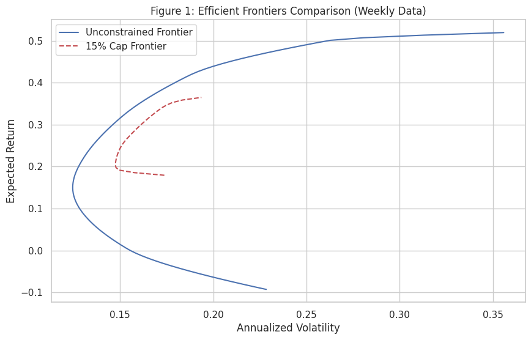

```python
# STEP 3: EFFICIENT FRONTIER
def get_efficient_frontier(mu, cov, bounds, num_points=100):
    target_rets = np.linspace(mu.min(), mu.max(), num_points)
    vols = []
    rets_clean = []
    for r in target_rets:
        cons = ({'type': 'eq', 'fun': lambda x: np.sum(x) - 1},
                {'type': 'eq', 'fun': lambda x: np.dot(x, mu) - r})
        res = minimize(lambda w: np.sqrt(np.dot(w.T, np.dot(cov, w))), w0,
                       bounds=bounds, constraints=cons, method='SLSQP')
        if res.success:
            vols.append(res.fun)
            rets_clean.append(r)
    return rets_clean, vols

ef1_ret, ef1_vol = get_efficient_frontier(mu, cov, bounds_step1)
ef2_ret, ef2_vol = get_efficient_frontier(mu, cov, bounds_step2)

plt.figure(figsize=(10, 6))
plt.plot(ef1_vol, ef1_ret, 'b-', label='Unconstrained Frontier')
plt.plot(ef2_vol, ef2_ret, 'r--', label='15% Cap Frontier')
plt.title("Figure 1: Efficient Frontiers Comparison (Weekly Data)")
plt.xlabel("Annualized Volatility")
plt.ylabel("Expected Return")
plt.legend()
plt.show()
```

The efficient frontier (Figure 1) gotten under the 15% maximum weight constraint lies firmly inside the unrestricted long-only efficient frontier. For any specified level of portfolio risk, the unrestricted frontier offers a higher expected return, whereas for any prearranged expected return, it attains a lower level of risk. This alteration arises due to the additional upper-bound constraint lessens the feasible investment set. By constraining portfolio concentration, the optimizer is barred from attaining the most efficient risk–return combinations obtainable under fewer constraints (Lehalle et al., 443-463). The contrast demonstrates the classic trade-off between diversification rules and mean–variance efficiency.

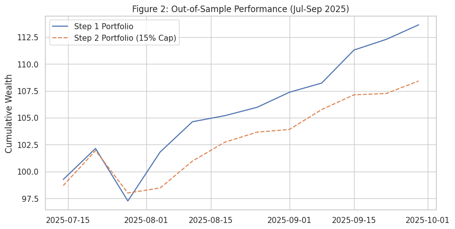

```
 Table 3: Out-of-Sample Performance Summary
```

|  | Total Return (3 Months) | Weekly Volatility | Annualized Volatility |
| --- | --- | --- | --- |
| Step 1 (Unconstrained) | 13.64% | 2.35% | 16.92% |
| Step 2 (Max 15%) | 8.42% | 1.87% | 13.49% |

```python
# STEP 4: OUT-OF-SAMPLE

returns_test = test_data.pct_change().dropna()

portfolio_ret_1 = returns_test.dot(weights_1)
portfolio_ret_2 = returns_test.dot(weights_2)

performance = pd.DataFrame({
    "Step 1 (Unconstrained)": portfolio_ret_1,
    "Step 2 (Max 15%)": portfolio_ret_2
})

wealth_1 = (1 + performance["Step 1 (Unconstrained)"]).cumprod() * 100
wealth_2 = (1 + performance["Step 2 (Max 15%)"]).cumprod() * 100

plt.figure(figsize=(10, 5))
plt.plot(wealth_1, label='Step 1 Portfolio')
plt.plot(wealth_2, label='Step 2 Portfolio (15% Cap)', linestyle='--')
plt.title("Figure 2: Out-of-Sample Performance (Jul-Sep 2025)")
plt.ylabel("Cumulative Wealth")
plt.legend()
plt.show()

summary_stats = pd.DataFrame({
    "Total Return (3 Months)": (1 + performance).prod() - 1,
    "Weekly Volatility": performance.std(),
    "Annualized Volatility": performance.std() * np.sqrt(52)
})

print("\n Table 3: Out-of-Sample Performance Summary")
display(summary_stats.style.format("{:.2%}"))
```

# **Part 2**

To solve this step we continue using the data used in the Part 1, so make sure that you have runned the code of part 1.

## **Step 4: Model and factors**

To explain the excess of returns of the portfolio ($R_p - R_f$), we used the 5 factor model proposed by Fama e French (12), equation 6, which is an extention of the the 3 factor model proposed by Fama e French (27) in 1993, equation 4 in Fama e French (12).

$$E[R_p] - R_f = \alpha + \beta_{Mkt}(R_m - R_f) + \beta_{SMB}SMB + \beta_{HML}HML + \beta_{RMW}RMW + \beta_{CMA}CMA + \epsilon,$$

where:

- $E[R_p] - R_f$ is risk free excess return of the portolio
- $\alpha$: is intercept, that's, anormal return not explained by factors, where if positive and significant at any confidence level it suggest that the performance is adjusted to the risk.
- $R_m - R_f$, is market risk after removing the risk free.
- SMB mean Small Minus Big and refer to historical returns of smal campanies compared to big campanies.
- HML mean High Minus Low and and measure the difference between high book to maket and low book to mark.
- RMW mean Robust Minus and measure the difference between high profitable campaneis and low profitable campanies.
- CMA men Conservative Minus Aggressive and measure the difference beteeen campanies that invest concervatevely and those that not (Fama and French 2-3).

```
Data successfully aligned! Rows: 104

 Table 4: Factor Correlation Matrix
```

|  | Mkt-RF | SMB | HML | RMW | CMA |
| --- | --- | --- | --- | --- | --- |
| Mkt-RF | 1.0000 | 0.1601 | -0.2485 | -0.4911 | 0.1029 |
| SMB | 0.1601 | 1.0000 | 0.4162 | -0.5048 | 0.2327 |
| HML | -0.2485 | 0.4162 | 1.0000 | 0.0207 | 0.2150 |
| RMW | -0.4911 | -0.5048 | 0.0207 | 1.0000 | -0.2780 |
| CMA | 0.1029 | 0.2327 | 0.2150 | -0.2780 | 1.0000 |

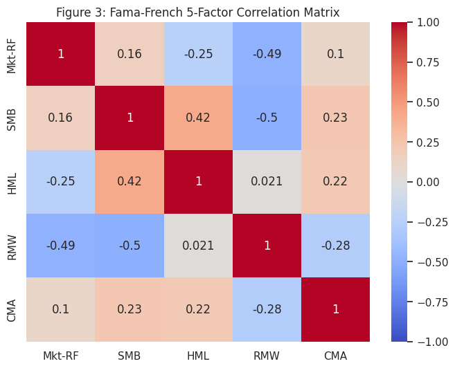

```python
import pandas_datareader.data as web
import statsmodels.api as sm
from pandas_datareader._utils import RemoteDataError
import warnings
warnings.filterwarnings("ignore")

portfolio_returns_train = returns_train.dot(weights_2)
portfolio_returns_train.name = "Portfolio_Return"

try:
    ff_data_daily = web.DataReader('F-F_Research_Data_5_Factors_2x3_daily',
                                   'famafrench',
                                   start='2023-07-01',
                                   end='2025-06-30')[0]
except RemoteDataError:
    print("Check your internet or try again later.")


ff_data_daily = ff_data_daily / 100

ff_data_weekly = ff_data_daily.resample('W').apply(lambda x: (1 + x).prod() - 1)

ff_data_weekly = ff_data_weekly.reindex(portfolio_returns_train.index, method='nearest')

regression_data = pd.concat([portfolio_returns_train, ff_data_weekly], axis=1).dropna()

if len(regression_data) == 0:
    print("Data intersection is still empty. Check date ranges.")
else:
    print(f"Data successfully aligned! Rows: {len(regression_data)}")

Y = regression_data['Portfolio_Return'] - regression_data['RF']
X = regression_data[['Mkt-RF', 'SMB', 'HML', 'RMW', 'CMA']]
X = sm.add_constant(X)

# STEP 4
print("\n Table 4: Factor Correlation Matrix")
corr_matrix = X.drop('const', axis=1).corr()
display(corr_matrix.round(4))

plt.figure(figsize=(8, 6))
sns.heatmap(corr_matrix, annot=True, cmap='coolwarm', vmin=-1, vmax=1)
plt.title("Figure 3: Fama-French 5-Factor Correlation Matrix")
plt.show()
```

## **Step 5**

To solve the step 5 we used weights ($w$) calculated in part 1 to produce times series of weekly returns of the portfolio. Fama and French factors (daily frequence) was converted in weekly frequence and listed to portfolio dates using nearest neighbor interpolation for consistence between times series.

### **Ordinary learst squares**

As asked in the project, we fitted Ordinary learst squares (OLS) model, which consiste in finding $\beta$ coeficientes that minimize the some of resídual squares:

$$\min_{\beta} \sum_{t=1}^{N} \epsilon_t^2 = \min_{\beta} \sum_{t=1}^{N} \left( Y_t - (\alpha + \beta_1 X_{1,t} + \dots + \beta_5 X_{5,t}) \right)^2, $$

where $Y_t$ is excess of return of the portfolio and $X_{i,t}$ are 5 risk factors described above.

Because this function as square erros, outliers have disproportional large weights in cost function, which we are minimizing. This disproportional large errors can distorce $\beta$ coeficientes if the residual distribtion is not Gaussian (Huber 155).

### **Robust estimation**

To avoid OLS sensibility to market extreme events we fitted Robust Linear Model (RLM) based on Huber. In Huber's estimator, we minimize the loss function $\rho$ which is less sensible to outliers (Huber 162):

$$\min_{\beta} \sum_{t=1}^{N} \rho \left( \frac{\epsilon_t}{\hat{\sigma}} \right)$$

We used Huber influencial function defined as:

$$\rho(z) = \begin{cases} \frac{1}{2}z^2 & \text{se } |z| \leq k \\ k|z| - \frac{1}{2}k^2 & \text{se } |z| > k \end{cases}, $$

Where $k$ is the cutoff. If error is small the model is OLS, and if the error is outlier (above $K$) the model penalize the error linearly, reduzing the its impact in $\beta$ estimative (Huber 177).

```
 Table 5: OLS regression results
                            OLS Regression Results
==============================================================================
Dep. Variable:                      y   R-squared:                       0.087
Model:                            OLS   Adj. R-squared:                  0.040
Method:                 Least Squares   F-statistic:                     1.859
Date:                Thu, 12 Feb 2026   Prob (F-statistic):              0.109
Time:                        14:33:46   Log-Likelihood:                 250.56
No. Observations:                 104   AIC:                            -489.1
Df Residuals:                      98   BIC:                            -473.2
Df Model:                           5
Covariance Type:            nonrobust
==============================================================================
                 coef    std err          t      P>|t|      [0.025      0.975]
------------------------------------------------------------------------------
const          0.0040      0.002      1.756      0.082      -0.001       0.009
Mkt-RF        -0.1743      0.117     -1.486      0.140      -0.407       0.058
SMB           -0.1916      0.178     -1.074      0.286      -0.546       0.163
HML           -0.1964      0.166     -1.183      0.240      -0.526       0.133
RMW           -0.6373      0.263     -2.419      0.017      -1.160      -0.115
CMA            0.0784      0.252      0.311      0.756      -0.421       0.578
==============================================================================
Omnibus:                       28.591   Durbin-Watson:                   2.040
Prob(Omnibus):                  0.000   Jarque-Bera (JB):               80.827
Skew:                          -0.926   Prob(JB):                     2.81e-18
Kurtosis:                       6.902   Cond. No.                         138.
==============================================================================

Notes:
[1] Standard Errors assume that the covariance matrix of the errors is correctly specified.

================================================================================

 Table 6: Robust regression results
                    Robust linear Model Regression Results
==============================================================================
Dep. Variable:                      y   No. Observations:                  104
Model:                            RLM   Df Residuals:                       98
Method:                          IRLS   Df Model:                            5
Norm:                          HuberT
Scale Est.:                       mad
Cov Type:                          H1
Date:                Thu, 12 Feb 2026
Time:                        14:33:46
No. Iterations:                    30
==============================================================================
                 coef    std err          z      P>|z|      [0.025      0.975]
------------------------------------------------------------------------------
const          0.0047      0.002      2.309      0.021       0.001       0.009
Mkt-RF        -0.1389      0.104     -1.334      0.182      -0.343       0.065
SMB           -0.2212      0.158     -1.396      0.163      -0.532       0.089
HML           -0.1260      0.147     -0.854      0.393      -0.415       0.163
RMW           -0.4935      0.234     -2.110      0.035      -0.952      -0.035
CMA            0.0791      0.224      0.354      0.724      -0.359       0.517
==============================================================================

If the model instance has been used for another fit with different fit parameters, then the fit options might not be the correct ones anymore .
 Table 7: Comparative differences analysis between OLS vs Robust
```

|  | OLS Coef | Robust Coef | Diff (Abs) | Diff (%) |
| --- | --- | --- | --- | --- |
| const | 0.0040 | 0.0047 | 0.0007 | 14.3665 |
| Mkt-RF | -0.1743 | -0.1389 | 0.0354 | 25.4951 |
| SMB | -0.1916 | -0.2212 | 0.0296 | 13.3954 |
| HML | -0.1964 | -0.1260 | 0.0705 | 55.9430 |
| RMW | -0.6373 | -0.4935 | 0.1438 | 29.1282 |
| CMA | 0.0784 | 0.0791 | 0.0007 | 0.8812 |

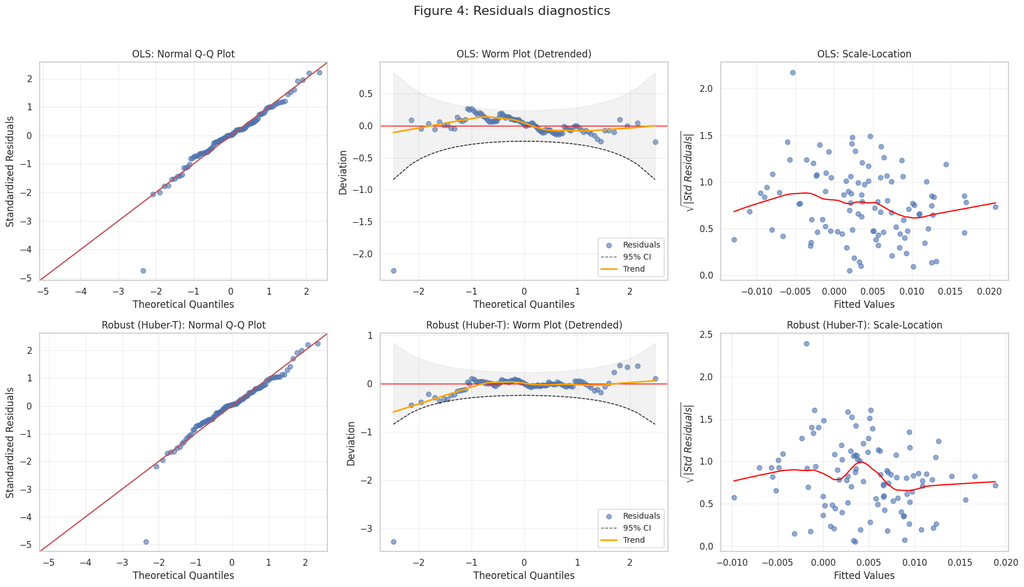

```python
%pip install statsmodels --quiet
import matplotlib.pyplot as plt
import scipy.stats as stats
import statsmodels.api as sm
import numpy as np
from statsmodels.nonparametric.smoothers_lowess import lowess

# OLS Regression
model_ols = sm.OLS(Y, X).fit()

# Robust Regression (Huber-T)
model_robust = sm.RLM(Y, X, M=sm.robust.norms.HuberT()).fit()

print(" Table 5: OLS regression results")
print(model_ols.summary())
print("\n" + "="*80 + "\n")
print(" Table 6: Robust regression results")
print(model_robust.summary())

print(" Table 7: Comparative differences analysis between OLS vs Robust")
diff_df = pd.DataFrame({
    'OLS Coef': model_ols.params,
    'Robust Coef': model_robust.params,
    'Diff (Abs)': np.abs(model_ols.params - model_robust.params),
    'Diff (%)': np.abs((model_ols.params - model_robust.params) / model_robust.params) * 100
})
display(diff_df.round(4))


def create_diagnostic_plots(model, ax_row, model_name):
    """
     Q-Q Plot, Worm Plot and Scale-Location.
    """

    if isinstance(model.model, sm.RLM):
        resid = model.resid
        scale = model.scale
        if scale < 1e-10: scale = 1.0
        std_resid = resid / scale
    else:
        influence = model.get_influence()
        std_resid = influence.resid_studentized_internal

    fitted = model.fittedvalues
    n = len(std_resid)

    sm.qqplot(std_resid, line='45', fit=True, ax=ax_row[0], alpha=0.6)
    ax_row[0].set_title(f"{model_name}: Normal Q-Q Plot")
    ax_row[0].set_ylabel("Standardized Residuals")
    ax_row[0].grid(True, alpha=0.3)


    (osm, osr) = stats.probplot(std_resid, dist="norm", fit=False)

    worm_y = osr - osm

    p_values = stats.norm.cdf(osm)
    pdf_values = stats.norm.pdf(osm)
    se = (1 / pdf_values) * np.sqrt(p_values * (1 - p_values) / n)
    upper_bound = 1.96 * se
    lower_bound = -1.96 * se

    ax_row[1].scatter(osm, worm_y, alpha=0.6, edgecolors='b', label='Residuals')
    ax_row[1].plot(osm, lower_bound, 'k--', alpha=0.7, linewidth=1, label='95% CI')
    ax_row[1].plot(osm, lower_bound, 'k--', alpha=0.7, linewidth=1)
    ax_row[1].axhline(0, color='red', linestyle='-', linewidth=1)

    ax_row[1].fill_between(osm, lower_bound, upper_bound, color='gray', alpha=0.1)

    try:
        smooth = lowess(worm_y, osm, frac=0.4)
        ax_row[1].plot(smooth[:, 0], smooth[:, 1], color='orange', linewidth=2, label='Trend')
    except:
        pass

    ax_row[1].set_title(f"{model_name}: Worm Plot (Detrended)")
    ax_row[1].set_xlabel("Theoretical Quantiles")
    ax_row[1].set_ylabel("Deviation")
    ax_row[1].legend(loc='lower right', fontsize='small')
    ax_row[1].grid(True, alpha=0.3)

    sqrt_abs_resid = np.sqrt(np.abs(std_resid))
    ax_row[2].scatter(fitted, sqrt_abs_resid, alpha=0.6)

    try:
        smooth_sl = lowess(sqrt_abs_resid, fitted, frac=0.4)
        ax_row[2].plot(smooth_sl[:, 0], smooth_sl[:, 1], color='red')
    except:
        pass

    ax_row[2].set_title(f"{model_name}: Scale-Location")
    ax_row[2].set_xlabel("Fitted Values")
    ax_row[2].set_ylabel("$\sqrt{|Std\ Residuals|}$")
    ax_row[2].grid(True, alpha=0.3)

fig, axes = plt.subplots(nrows=2, ncols=3, figsize=(18, 10))

create_diagnostic_plots(model_ols, axes[0], "OLS")

create_diagnostic_plots(model_robust, axes[1], "Robust (Huber-T)")

fig.suptitle("Figure 4: Residuals diagnostics", fontsize=16, y=1.02)
plt.tight_layout()
plt.show()
```

## **Step 5**

Comparing OLS estimatives (Table 5) we see problems of residuals normality, which is confirmed by Jarque-Bera test. So to avoid report biased estimates, we used robust regression estimates (Tabela 6). We can see in Figure 4 that Q-Q Plot and the Worm Plot show lower taill (some points outside the confidence bands in Worm plot ), which indicate the presence of excess kurtose. Although the robust does not eliminate them, it weights their influence as described above.

## **Step 6**

From robust model estimates (Tabela 6) we can see that:

- Intercept $(\alpha = 0.0047)$ was significative at 5% of significance level (p-value = 0.021), meaning that during the analysed period, the portfolio produced an weekly excess return of aproximatly 0.47% not explained by risk factors, which can be atributed to specific asset selection or technology being used.
- Profitable factor $(\beta_{RMW} =-0.4935)$, also signifcative at 5% of significance level (p-value = 0.035). The negative sinal suggest that portfolio behaves in oposite way to the campanies profitability defined by Farma-French model.
- Small Minus Big, $SMB= -0.2212$ and market risk after removing risk free $(Mkt-RF=-0.1389)$, was not significantive at 5% of significance level (p=0.16), which mean respectively that for time period considered here (weekly analysis), the portfólio returns is not influencied by tthe size of campanies and portfolio risk is influencied by companie not by market stock.
- High Minus Low ($HML$) and Conservative Minus Aggressive (CMA), both was not significative at 5% of significance level (p-values 0.39 e 0.72, respectively), meaning respectively that the investiment style (low or high profitability) and behavore of investment (agressive or conservative) do not explain why portfolio went up or down.

# **Part 3**

In this step we continue using weekly data (see Part 1 and 2), and 5 assets (AAPL, GOOG, META, XOM, LLY) from july 2023 to june 2025. Using this data, we calculated the annulized returns means ($\mu$) and covariance matriz ($\Sigma$). To maximize the Sharpe Index (minimize the negative Sharpe index), we used the Sequential Least Squares Programming (SLSQP) algoritm $$-\frac{w^T \mu}{\sqrt{w^T \Sigma w}}, \: \: \text{ and restriction } \sum w_i = 1, \: \: \: w_i \ge 0.$$

We also used Monte Carlo simulations, where our samples was batch do avoid problem with RAM memory.

The efficience (performance) of simulation where measured using Euclidian distance $$||w_{sim} - w_{opt}||$$

between the simulated weights for diferents sizes of the samples ($N$), which helped us to see the convergence of the stocastic method.

```
Downloading data for: ['AAPL', 'GOOG', 'META', 'XOM', 'LLY']
  Sims: 1000 | Error: 0.1258
  Sims: 5000 | Error: 0.1105
  Sims: 10000 | Error: 0.1261
  Sims: 50000 | Error: 0.0697
  Sims: 100000 | Error: 0.0663
```

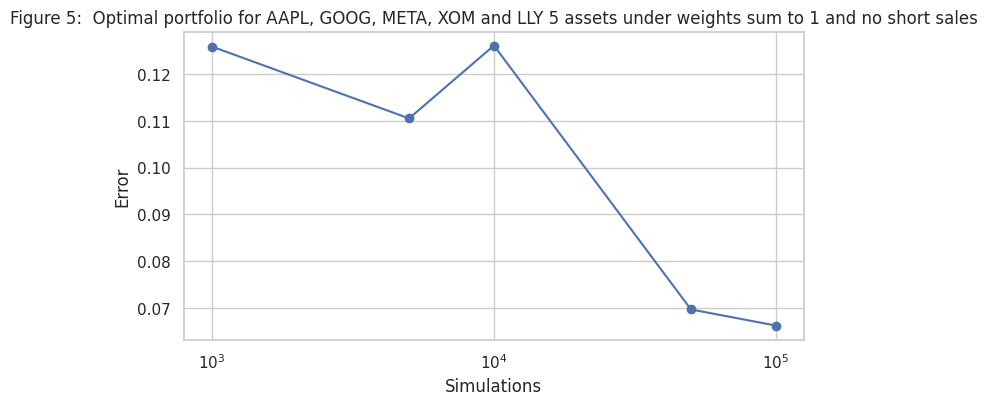

```python
import numpy as np
import pandas as pd
import yfinance as yf
import matplotlib.pyplot as plt
import seaborn as sns
from scipy.optimize import minimize

sns.set(style="whitegrid")
np.random.seed(42)

# DATA
assets = ["AAPL", "GOOG", "META", "XOM", "LLY"]
start_date = "2023-07-01"
end_date = "2025-06-30"

print(f"Downloading data for: {assets}")
data = yf.download(assets, start=start_date, end=end_date, interval="1wk", progress=False)['Close']

if isinstance(data.columns, pd.MultiIndex):
    data.columns = data.columns.get_level_values(0)

returns = data.pct_change().dropna()
mu = returns.mean().values * 52
cov = returns.cov().values * 52
n_assets = len(assets)
w0 = np.ones(n_assets) / n_assets

def neg_sharpe(weights, mu, cov):
    ret = np.dot(weights, mu)
    vol = np.sqrt(np.dot(weights.T, np.dot(cov, weights)))
    return -(ret / vol)

# Simulation
sim_sizes = [1000, 5000, 10000, 50000, 100000]

def run_simulation_batches(n_total, mu, cov, max_cap=None, batch_size=10000):
    """
    Runs simulation in small batches to prevent RAM crashes.
    """
    best_sharpe = -np.inf
    best_weights = None

    sims_done = 0

    while sims_done < n_total:
        current_batch = min(batch_size, n_total - sims_done)

        raw_size = current_batch
        if max_cap:
            raw_size = current_batch * 10

        w_batch = np.random.random((raw_size, n_assets))
        w_batch = w_batch / w_batch.sum(axis=1)[:, None]

        if max_cap:
            mask = np.all(w_batch <= max_cap, axis=1)
            w_batch = w_batch[mask]

            if len(w_batch) == 0:
                continue

        p_ret = np.dot(w_batch, mu)
        p_vol = np.sqrt(np.einsum('ij,jk,ik->i', w_batch, cov, w_batch))
        sharpe = p_ret / p_vol

        idx = np.argmax(sharpe)
        current_best_sharpe = sharpe[idx]

        if current_best_sharpe > best_sharpe:
            best_sharpe = current_best_sharpe
            best_weights = w_batch[idx]

        sims_done += len(w_batch) if max_cap else current_batch

    return best_weights

# STEP 7
cons = ({'type': 'eq', 'fun': lambda x: np.sum(x) - 1})
bounds_7 = tuple((0, 1) for _ in range(n_assets))
opt_7 = minimize(neg_sharpe, w0, args=(mu, cov), method='SLSQP', bounds=bounds_7, constraints=cons)
weights_opt_7 = opt_7.x

errors_7 = []
for n in sim_sizes:
    w_sim = run_simulation_batches(n, mu, cov, max_cap=None)
    error = np.linalg.norm(w_sim - weights_opt_7)
    errors_7.append(error)
    print(f"  Sims: {n} | Error: {error:.4f}")

plt.figure(figsize=(8, 4))
plt.plot(sim_sizes, errors_7, marker='o')
plt.xscale('log')
plt.title("Figure 5:  Optimal portfolio for AAPL, GOOG, META, XOM and LLY 5 assets under weights sum to 1 and no short sales")
plt.xlabel("Simulations")
plt.ylabel("Error")
plt.show()
```

From Figure 5 we see that the simulations converge to the optimal solution as the number os simulations increase, but the process is not linear because of randomization, requiring between 50.000 to 10000 simulations to achieve low error.

### **Step 8**

```
  Sims: 1000 | Error: 0.0511
  Sims: 5000 | Error: 0.0325
  Sims: 10000 | Error: 0.0433
  Sims: 50000 | Error: 0.0143
  Sims: 100000 | Error: 0.0326
```

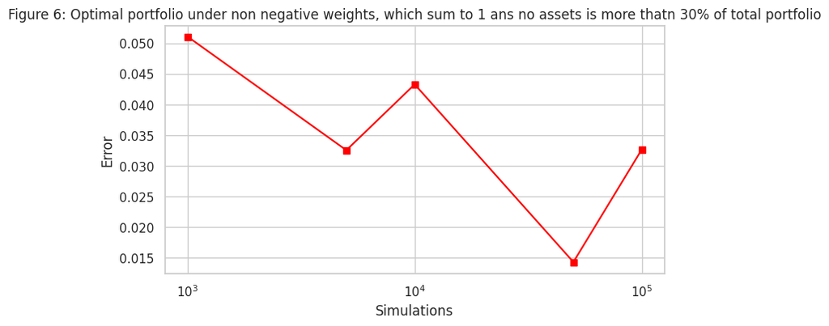

```python
# STEP 8

# Optimization
bounds_8 = tuple((0, 0.30) for _ in range(n_assets))
opt_8 = minimize(neg_sharpe, w0, args=(mu, cov), method='SLSQP', bounds=bounds_8, constraints=cons)
weights_opt_8 = opt_8.x

# Simulation Loop
errors_8 = []
for n in sim_sizes:
    w_sim = run_simulation_batches(n, mu, cov, max_cap=0.30)

    if w_sim is None:
        errors_8.append(np.nan)
        continue

    error = np.linalg.norm(w_sim - weights_opt_8)
    errors_8.append(error)
    print(f"  Sims: {n} | Error: {error:.4f}")

plt.figure(figsize=(8, 4))
plt.plot(sim_sizes, errors_8, marker='s', color='red')
plt.xscale('log')
plt.title("Figure 6: Optimal portfolio under non negative weights, which sum to 1 ans no assets is more thatn 30% of total portfolio")
plt.xlabel("Simulations")
plt.ylabel("Error")
plt.show()
```

### **Step 7 and 8 results**

```python
print("\nTable 5: Optimal Weights Comparison")
df_comp = pd.DataFrame({
    'Asset': assets,
    'Step 7 (Opt)': weights_opt_7,
    'Step 8 (Opt)': weights_opt_8
})
print(df_comp.round(4))
```

[output not shown]

We can see in Table 5 that for Step 7, the the optimizer strongly prefers XOM, followed by META and LLY, with almost no allocation to AAPL.

When I tried to approximate this using simulation, the weights got closer as the number of simulations increased, but not in a perfectly smooth way (Figure 5).

This fluctuation happens because simulation is random. More simulations increase the chance of finding a portfolio near the true optimum, but there is no guarantee that every increase in sample size will produce a better result.

Overall, the takeaway is:

- Simulation can approximate the optimal weights reasonably well.
- Around 50,000–100,000 simulations seems sufficient to get fairly close to the optimizer.
- Optimization is still much more precise and efficient, since it directly finds the best solution instead of searching randomly.

For step 8, compared to Step 7 (Table 5), the new constraint clearly changed the structure of the portfolio. In Step 7, XOM had nearly 48%, but now it is capped at 30%, so the extra weight is redistributed across GOOG, META, and LLY. This makes the allocation more balanced.

The key point is that, despite the extra constraints, simulation still found portfolios quite close to the optimized solution. The distances remained small overall, generally between about 0.01 and 0.05.

From both steps, a few clear insights emerge:

- Optimization consistently gives a precise solution quickly.
- It directly computes the best weights that satisfy all constraints.
- Simulation can get close, but it relies on luck and volume. You need tens of thousands of simulations to reliably approximate the optimal portfolio.
- More simulations help, but not in a perfectly smooth way. Because the method is random, sometimes 50k simulations may look better than 100k.
- Adding constraints changes the shape of the portfolio.

In Step 8, the 30% cap forced diversification, especially reducing the dominance of XOM.

Rough practical takeaway:

- ~50k simulations: reasonably close to optimal
- ~100k+: very good approximation in most cases
- Optimization remains the more efficient and stable approach

So, simulations can be used as an alternative to optimization, but they require a large number of trials to get close to the same result, especially when the portfolio space becomes more restricted.

# **Conclusions**

This analysis establishes that portfolio optimization effect is vastly sensitive to enforced constraints. Long-only constraints already lessen the feasible investment set, while further upper-bound constraints further limit effectiveness but boost diversification. The comparison of efficient frontiers and out-of-sample performance underscores the necessity of balancing theoretical optimality with practical investment contemplations and client-specific necessities.

The application of 5 factor Fama-French showed that robust regression is best than OLS, for non-normality in financial returns, insolating the random the probitablity factor and alpha as significant drivers.

In Part 3, althout the Monte Carlo simulations convirged to optimal solution, it was necessary between 50.000 to 100.000 iterations, which is computationaly expansive and stocasticlaly instable for rigde restrictions.

# **References**

Fama, Eugene F., and Kenneth R. French. "A five-factor asset pricing model." *Journal of financial economics* 116.1 (2015): 1-22.

Fama, Eugene F., and Kenneth R. French. "Common risk factors in the returns on stocks and bonds." *Journal of financial economics* 33.1 (1993): 3-56.

Huber, Peter J. *Robust Statistics*. John Wiley & Sons, 1981.

Al Janabi, Mazin AM. "Insights into Liquidity Dynamics: Optimizing Asset Allocation and Portfolio Risk Management with Machine Learning Algorithms." *Liquidity Dynamics and Risk Modeling: Navigating Trading and Investment Portfolios Frontiers with Machine Learning Algorithms. Cham: Springer Nature Switzerland*, 2024. 257-303.

Etienne, Alban, et al. "Revisiting the Structure of Trend Premia: When Diversification Hides Redundancy." arXiv preprint arXiv:2510.23150 (2025). Lehalle, Charles-Albert, and Guillaume Simon. "Portfolio selection with active strategies: how long only constraints shape convictions." *Journal of Asset Management* 22.6 (2021): 443-463.

Uykun, Firdevs Nur. Machine Learning Applications in Portfolio Optimization. MS thesis. Middle East Technical University (Turkey), 2024.